# CUNY 606 Final Exam

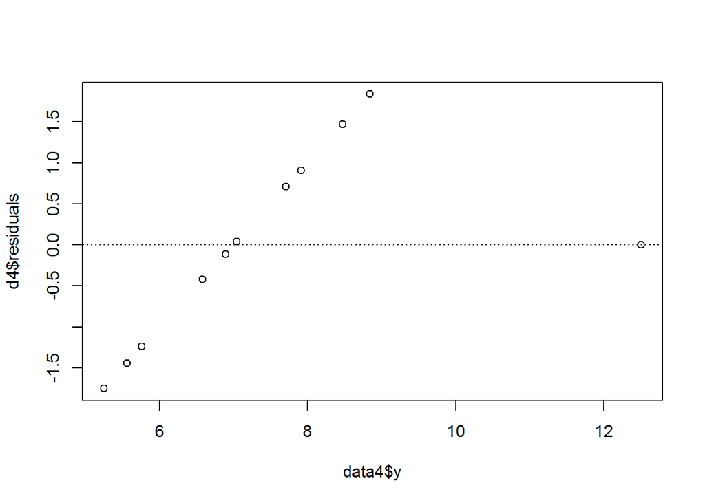

```r
plot(d4$residuals ~ data4$y)
abline(h = 0, lty = 3)
```

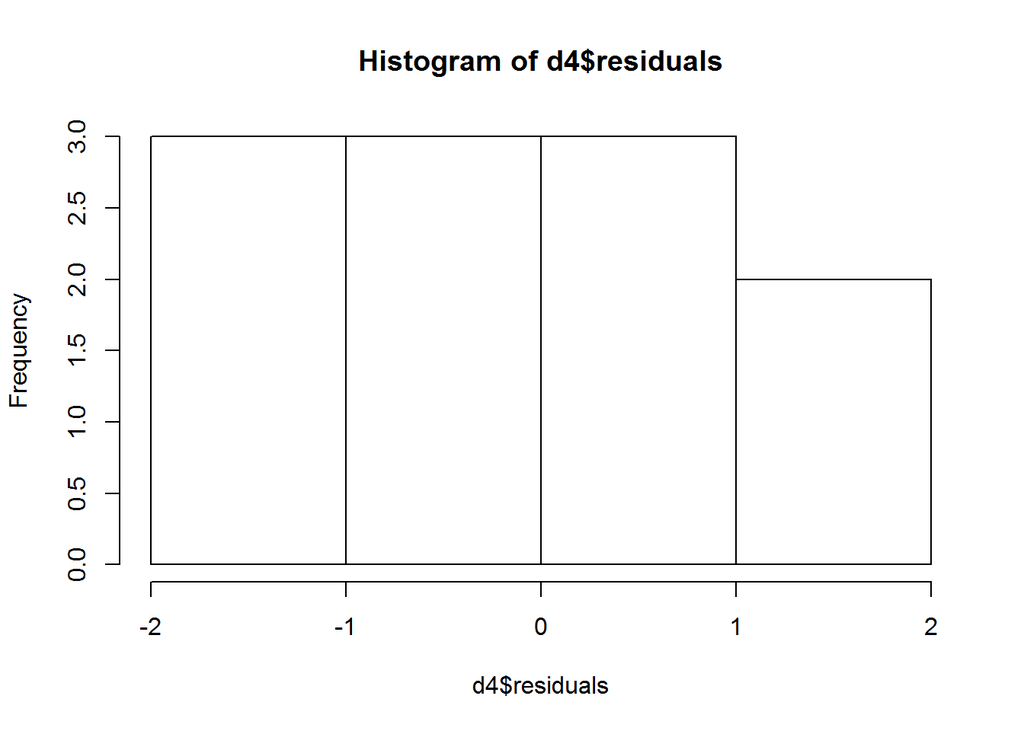

```r
#Nearly normal residuals
hist(d4$residuals)
```

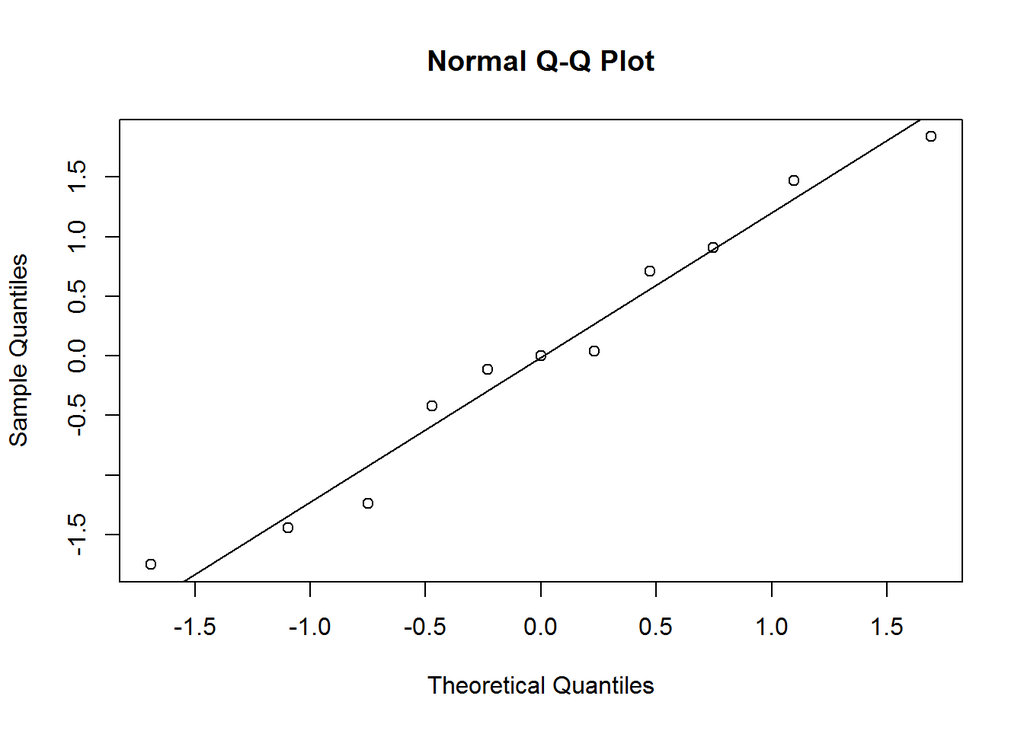

```r
qqnorm(d4$residuals)
qqline(d4$residuals)
```

Data 4: Again, there is not constant variability. so again I would conclude that it is inappropriate to estimate a linear regression model.

Explain why it is important to include appropriate visualizations when analyzing data. Include any visualization(s) you create.

I would suggest that the answers above clearly illustrate why it is important to include appropirate visualizations. By just looking at the linear equations and R-squared values, you would assume that (a) all four data sets would be almost identical since they each had a similar linear regression equation associated with them. As we subsequently saw when making scatterplots, not only are all these data sets very different, but not all of them were appropriate to associate with linear models. This fact would have been lost if not for the scatteplots of x against y and residuals against y.